# Generalized Linear Modeling for French Motor Claim Frequency

ACT 560: Regression Modeling: Insurance

Mobasshira Zaman

29 October 2025

# 1 Executive Summary

This project analyzes how driver, vehicle, and regional characteristics affect the likelihood of motor insurance claims. Using data from a large French auto insurance portfolio, the goal was to identify the key risk drivers and recommend a reliable model that supports fair pricing and stronger portfolio management.

Three modeling approaches were tested. The standard model provided a baseline, while enhanced versions were developed to better handle differences in risk and the large share of customers who make no claims. Among these, the Zero-Inflated Poisson (ZIP) model performed best, offering the most accurate and balanced results. The analysis found that claim frequency is most influenced by driver age, vehicle age, fuel type, and vehicle power, with clear regional variations. Adopting the ZIP model enables more precise rate-setting, improves identification of low- and high-risk segments, and supports more efficient capital use.

This project demonstrates a data-driven approach that can strengthen underwriting discipline, enhance pricing fairness, and improve overall profitability through more informed risk segmentation. It is recommended that stakeholders adopt the ZIP modeling framework as a decision-support tool for future pricing reviews, product design, and portfolio risk monitoring, ensuring more sustainable and competitive business performance. This project helps us customize pricing and the portfolio by region and simple factors (driver age, car age, fuel type, power), so coverage better matches local risk.

# 2 Introduction

Modeling motor-insurance claim frequency is foundational to premium adequacy and fairness, as reliable estimates of expected claim counts underpin sustainable pricing (Marciuc, 2024). The accuracy of these models directly affects the insurer’s ability to manage portfolio risk, allocate capital efficiently, and remain competitive. The French motor dataset analyzed here has become a benchmark for claim frequency modeling, as it captures a large and diverse portfolio of private passenger vehicles across multiple regions, vehicle types, and driver demographics (FLOSER, 2019). Because the number of claims tends to be small and the majority of policyholders report zero claims, specialized count-data models such as Poisson, Negative Binomial, and Zero-Inflated Poisson are particularly suitable (Simmachan & Boonkrong, 2024).

Understanding the drivers of claim frequency is essential for fair pricing, solvency, and risk management. This project aims to quantify how policyholder and vehicle characteristics influence expected claim counts and to compare competing statistical models that address common issues such as over-dispersion and excess zeros. The study evaluates three approaches—a standard Poisson GLM, a Negative Binomial GLM, and a Zero-Inflated Poisson model—using cross-validation and test-set performance metrics. The goal is to identify a robust yet interpretable model that balances predictive accuracy with transparency, providing a reliable foundation for rate-making and portfolio monitoring in motor insurance practice.

```r
#import libraries
library(data.table)
library(ggplot2)
library(splines)
library(MASS)
library(DHARMa)
library(dplyr)
library(MASS)
library(pROC)
library(ggplot2)
library(patchwork)
library(boot)
require(pscl)
library(pROC)
```

# 3 Data Description

## 3.1 Data Source

Data were sourced from the freMTPL2freq Kaggle repository (FLOSER, 2019). The underlying source is the CASDatasets R package (version 1.0-6, 2016) (Dutang & Charpentier, 2016). Table 1 summarizes the variable definitions and measurement scales used in the freMTPL2freq dataset.  
Table 1: Variable definitions for the freMTPL2freq dataset

| Variable | Unit | Description |
| --- | --- | --- |
| IDpol | ID | Policy identifier (links to claim records). |
| ClaimNb | count | Number of claims during the exposure period. |
| Exposure | years | Length of time the policy is in force. |
| Area | code | Area class (A–F). |
| Region | code | Geographic region (insurer classification). |
| VehBrand | factor | Vehicle brand. |
| VehPower | class | Vehicle power class. |
| VehAge | years | Age of the vehicle. |
| VehGas | factor | Fuel type. |
| DrivAge | years | Age of the driver. |
| BonusMalus | index | Bonus–malus score (50–350; 100 = bonus, >100 = malus). |
| Density | pop/km² | Population density of the insured’s area. |

```r
# load data
df <- as.data.frame(readxl::read_excel("/Users/mobasshirazaman/Library/CloudStorage/OneDrive-NorthernIllinoisUniversity/ASU/Fall2025/ACT560/Project1MZ/freMTPL2freq.xlsx"))
```

## 3.2 Exploratory Data Analysis

The dataset has 678013 rows and 12 columns. For this project the target variable will be ClaimNb. The IDpol is a policy type without additional information available, hence, we will not consider this a modeling parameter as this will not provide any explainable information. The target variable is numerical, as well as seven other variables except Area, Region, VehBrand, VehGas.

```r
cat("Dataset shape: ", nrow(df), "rows x", ncol(df), "columns\n\n", sep=" ")
```

```
## Dataset shape:  678013 rows x 12 columns
```

```r
cat("Data Info: data type\n")
```

```
## Data Info: data type
```

```r
str(df)
```

```
## 'data.frame':    678013 obs. of  12 variables:
##  $ IDpol     : num  1 3 5 10 11 13 15 17 18 21 ...
##  $ ClaimNb   : num  1 1 1 1 1 1 1 1 1 1 ...
##  $ Exposure  : num  0.1 0.77 0.75 0.09 0.84 0.52 0.45 0.27 0.71 0.15 ...
##  $ Area      : chr  "D" "D" "B" "B" ...
##  $ VehPower  : num  5 5 6 7 7 6 6 7 7 7 ...
##  $ VehAge    : num  0 0 2 0 0 2 2 0 0 0 ...
##  $ DrivAge   : num  55 55 52 46 46 38 38 33 33 41 ...
##  $ BonusMalus: num  50 50 50 50 50 50 50 68 68 50 ...
##  $ VehBrand  : chr  "B12" "B12" "B12" "B12" ...
##  $ VehGas    : chr  "Regular" "Regular" "Diesel" "Diesel" ...
##  $ Density   : num  1217 1217 54 76 76 ...
##  $ Region    : chr  "R82" "R82" "R22" "R72" ...
```

```r
cat("\nMissing Values:\n")
```

```
##
## Missing Values:
```

```r
print(colSums(is.na(df)))
```

```
##      IDpol    ClaimNb   Exposure       Area   VehPower     VehAge    DrivAge
##          0          0          0          0          0          0          0
## BonusMalus   VehBrand     VehGas    Density     Region
##          0          0          0          0          0
```

```r
cat("\nCardinality:\n")
```

```
##
## Cardinality:
```

```r
sapply(df, function(x) length(unique(x)))
```

```
##      IDpol    ClaimNb   Exposure       Area   VehPower     VehAge    DrivAge
##     678013         11        187          6         12         78         83
## BonusMalus   VehBrand     VehGas    Density     Region
##        115         11          2       1607         22
```

The summary stattistics of the numerical varibales shows that most policyholders have relatively short exposure durations and few claims, which is typical for frequency data. ClaimNb is highly skewed, with a mean of only 0.05 but a maximum of 16, indicating that multiple-claim events are rare. Exposure averages about half a year, while vehicle and driver ages range broadly, with mean values near 7 and 46 years, respectively. The BonusMalus factor varies between 50 and 230, suggesting a wide range of driving risk classes, and Density spans from 1 to over 27,000 inhabitants per km², reflecting strong regional heterogeneity in population environments. Overall, the descriptive statistics highlight substantial variation across demographic and policy-related variables, with claim frequency remaining very low.

```r
# Numerical feature stats
cat("\nNumerical Features Statistics:\n")
```

```
##
## Numerical Features Statistics:
```

```r
nums <- sapply(df, is.numeric)
print(summary(df[ , nums, drop = FALSE]))
```

```
##      IDpol            ClaimNb            Exposure           VehPower
##  Min.   :      1   Min.   : 0.00000   Min.   :0.002732   Min.   : 4.000
##  1st Qu.:1157951   1st Qu.: 0.00000   1st Qu.:0.180000   1st Qu.: 5.000
##  Median :2272152   Median : 0.00000   Median :0.490000   Median : 6.000
##  Mean   :2621857   Mean   : 0.05325   Mean   :0.528750   Mean   : 6.455
##  3rd Qu.:4046274   3rd Qu.: 0.00000   3rd Qu.:0.990000   3rd Qu.: 7.000
##  Max.   :6114330   Max.   :16.00000   Max.   :2.010000   Max.   :15.000
##      VehAge           DrivAge        BonusMalus        Density
##  Min.   :  0.000   Min.   : 18.0   Min.   : 50.00   Min.   :    1
##  1st Qu.:  2.000   1st Qu.: 34.0   1st Qu.: 50.00   1st Qu.:   92
##  Median :  6.000   Median : 44.0   Median : 50.00   Median :  393
##  Mean   :  7.044   Mean   : 45.5   Mean   : 59.76   Mean   : 1792
##  3rd Qu.: 11.000   3rd Qu.: 55.0   3rd Qu.: 64.00   3rd Qu.: 1658
##  Max.   :100.000   Max.   :100.0   Max.   :230.00   Max.   :27000
```

We can have better understanding by observing the histograms for the numerical and bar plots for categorical variables. The histograms showed notable skewness and uneven distributions across variables. To address this, log transformation is applied to Density due to its heavy right tail. VehAge was grouped into three categories (0, 1–10, 11+) to capture its clustered pattern, while VehPower was converted into 2 categories (“low” ≤ 8, “high” > 8). Since only a few VehBrand categories appeared frequently, the top three brands been retained and grouped the rest as “Other.”

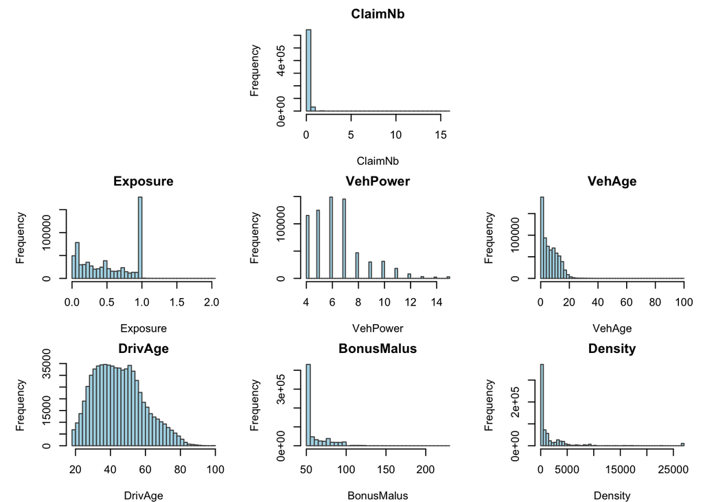

```r
#histogram
# vars
num_cols <- c("ClaimNb","Exposure","VehPower","VehAge","DrivAge","BonusMalus","Density")
others   <- setdiff(num_cols, "ClaimNb")
# layout: [ empty | ClaimNb | empty ] on row 1, then 3x2 grid below
mat <- matrix(c(
  0, 1, 0,
  2, 3, 4,
  5, 6, 7
), nrow = 3, byrow = TRUE)
layout(mat, widths = c(1,1,1), heights = c(1,1,1))

op <- par(mar = c(4, 5, 2, 1))  # bigger left margin fixes y-label cut
plot_hist <- function(x, title) {
  hist(x, breaks = 50, col = "lightblue", border = "gray30",
       main = title, xlab = title, ylab = "Frequency")
}

# top-center: ClaimNb
plot_hist(df$ClaimNb, "ClaimNb")

# the rest in order
plot_hist(df$Exposure,   "Exposure")
plot_hist(df$VehPower,   "VehPower")
plot_hist(df$VehAge,     "VehAge")
plot_hist(df$DrivAge,    "DrivAge")
plot_hist(df$BonusMalus, "BonusMalus")
plot_hist(df$Density,    "Density")
```

```r
par(op); layout(1)
par(op)
```

Figure 1: Histogram for numerical variables

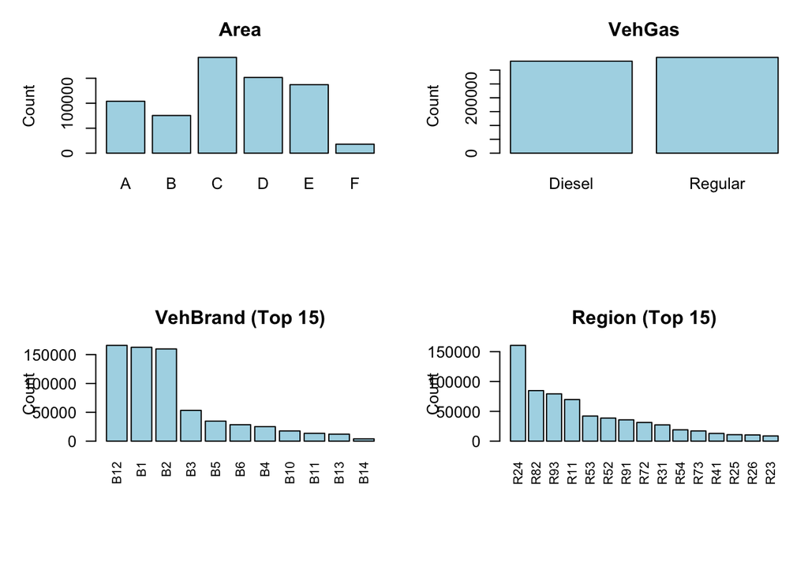

```r
# 1) pick categoricals
cat_cols <- c("Area","VehBrand","VehGas","Region")

# 2) helper to get counts (top N if many levels)
top_counts <- function(x, n = 15) {
  tb <- sort(table(x), decreasing = TRUE)
  if (length(tb) > n) tb[1:n] else tb
}

# 3) layout: 2x2 collage
op <- par(mfrow = c(2,2), mar = c(7, 5, 3, 1))  # bigger bottom for rotated names

# Area (small #levels)
barplot(table(df$Area),
        main = "Area",
        ylab = "Count",
        col = "lightblue")

# VehGas (small #levels)
barplot(table(df$VehGas),
        main = "VehGas",
        ylab = "Count",
        col = "lightblue")

# VehBrand (top 15)
barplot(top_counts(df$VehBrand, 15),
        main = "VehBrand (Top 15)",
        ylab = "Count",
        col = "lightblue",
        las = 2, cex.names = 0.8)

# Region (top 15)
barplot(top_counts(df$Region, 15),
        main = "Region (Top 15)",
        ylab = "Count",
        col = "lightblue",
        las = 2, cex.names = 0.8)
```

```r
par(op)
```

Figure 2: Bar plot for categorical variables.

The numerical varibales are also checked for outliers. ClaimNb has outliers but here this high number of claim cases should be kept as those can provide further information for the modeling, only claims more than 10 times are filtered out. Some of the predictors are selected for transformation but others are filtered to remove the outliers, such as driver’s age.

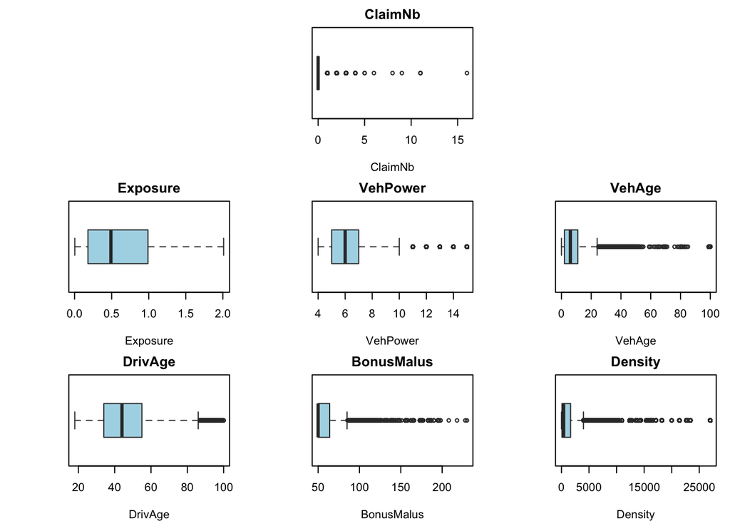

```r
# Boxplots to reveal outliers

num_cols <- c("ClaimNb","Exposure","VehPower","VehAge","DrivAge","BonusMalus","Density")
others   <- setdiff(num_cols, "ClaimNb")

# layout same as before: [ empty | ClaimNb | empty ], then grid
mat <- matrix(c(
  0, 1, 0,
  2, 3, 4,
  5, 6, 7
), nrow = 3, byrow = TRUE)
layout(mat, widths = c(1,1,1), heights = c(1,1,1))

op <- par(mar = c(4, 5, 2, 1))

plot_box <- function(x, title) {
  boxplot(x,
          col = "lightblue",
          border = "gray20",
          horizontal = TRUE,
          main = title,
          xlab = title)
}

# top-center
plot_box(df$ClaimNb, "ClaimNb")

# the rest in order
plot_box(df$Exposure,   "Exposure")
plot_box(df$VehPower,   "VehPower")
plot_box(df$VehAge,     "VehAge")
plot_box(df$DrivAge,    "DrivAge")
plot_box(df$BonusMalus, "BonusMalus")
plot_box(df$Density,    "Density")
```

```r
par(op)
layout(1)



# ClaimNb > 10 remove
df <- df %>%
  filter(ClaimNb <= 10)

# Driver's age outlier handling

library(DescTools)

winsor <- function(x, p = c(0.01, 0.99)) {
  qs <- stats::quantile(x, probs = p, na.rm = TRUE, names = FALSE)
  pmin(pmax(x, qs[1]), qs[2])
}

vars_to_cap <- c("DrivAge")
df[vars_to_cap] <- lapply(df[vars_to_cap], winsor)
```

Figure 3: Boxplots for checking outliers of numerical variables

```r
#transform predictors
top3 <- names(sort(table(df$VehBrand), decreasing = TRUE))[1:min(3, nlevels(factor(df$VehBrand)))]
df <- df %>%
  filter(Exposure > 0, Density > 0) %>%
  mutate(
    VehAge_grp  = cut(VehAge, c(-Inf, 0, 10, Inf), labels = c("0","1-10","11+"), right = TRUE),
    VehPower_hi = factor(ifelse(VehPower <= 8, "low", "high"), levels = c("low","high")),
    VehBrand3   = factor(ifelse(VehBrand %in% top3, as.character(VehBrand), "Other")),
    Density_log = log(Density)
  )
```

# 4 Methodology

## 4.1 Correlation and multicollinearity

The correlation matrix and VIF results showed moderate correlation between DrivAge and BonusMalus, and high multicollinearity for Area and Density_log (GVIF > 10). To reduce redundancy and improve model stability, BonusMalus, and Density_log have excluded from the GML model predictors.

```r
library(corrplot)
# numeric-only (post-transform)
num_df <- df %>%
  dplyr::select(where(is.numeric)) %>%      # keep numeric cols only
  dplyr::select(-Density) %>%               # prefer Density_log
  dplyr::select(where(~ var(., na.rm = TRUE) > 0))  # drop constants

# Pearson correlations
C <- cor(num_df, use = "pairwise.complete.obs", method = "pearson")
cat("Correlation Matrix:\n")
```

```
## Correlation Matrix:
```

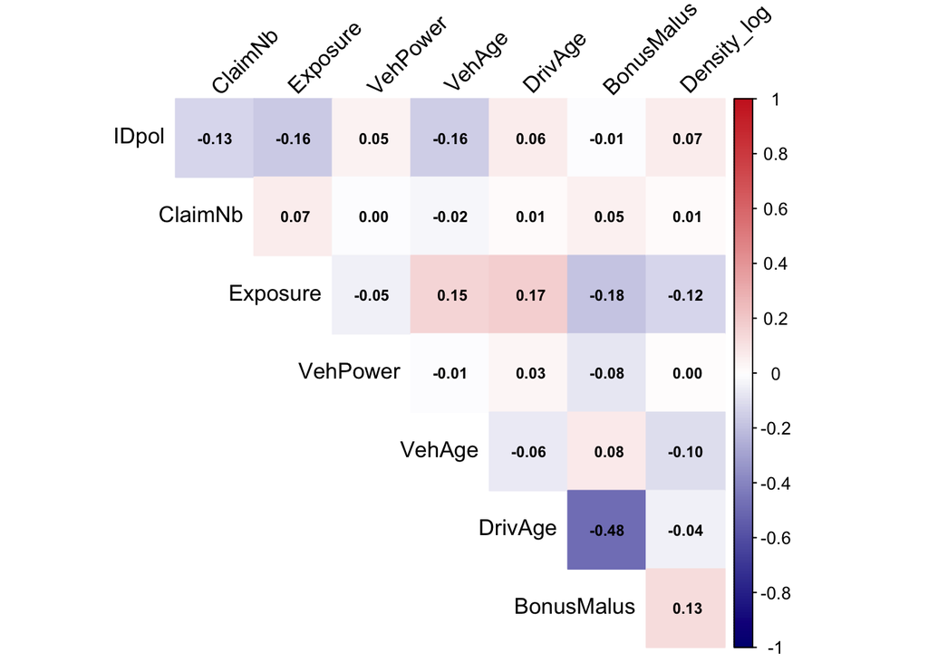

```r
# 4) Heatmap with coefficients
corrplot(C,
         method = "color", type = "upper", diag = FALSE,
         tl.col = "black", tl.srt = 45,
         col = colorRampPalette(c("navy","white","firebrick3"))(200),
         addCoef.col = "black", number.cex = 0.7, number.digits = 2
)
```

Figure 4: Correlation. The darker shade indicates stronger corraltion. Red is positive correlation and blue is negative correlation.

```r
library(car)
library(performance)

# keep Exposure>0 and cast factors
df <- df %>% filter(Exposure > 0) %>%
  mutate(
    Area     = factor(Area),
    Region   = factor(Region),
    VehBrand3 = factor(VehBrand3),
    VehGas   = factor(VehGas),
    VehPower_hi= factor(VehPower_hi),
    VehAge_grp= factor(VehAge_grp),
  )
base_form_full <- ClaimNb ~ Area+ Region + VehBrand3 + VehGas +
  DrivAge + VehAge_grp + VehPower_hi + Density_log

m_lm_full <- lm(base_form_full, data = df)
cat("VIF:\n")
```

```
## VIF:
```

```r
print(car::vif(m_lm_full))
```

```
##                  GVIF Df GVIF^(1/(2*Df))
## Area        25.897258  5        1.384603
## Region       2.213235 21        1.019096
## VehBrand3    1.427519  3        1.061118
## VehGas       1.059078  1        1.029115
## DrivAge      1.033085  1        1.016408
## VehAge_grp   1.227761  2        1.052637
## VehPower_hi  1.043816  1        1.021673
## Density_log 19.911920  1        4.462277
```

```r
performance::check_collinearity(m_lm_full)
```

| Term | VIF | VIF_CI_low | VIF_CI_high | SE_factor | Tolerance | Tolerance_CI_low | Tolerance_CI_high |
| --- | --- | --- | --- | --- | --- | --- | --- |
| Area | 25.897258 | 25.776653 | 26.018451 | 1.384603 | 0.03861413 | 0.03843426 | 0.03879480 |
| Region | 2.213235 | 2.205107 | 2.221418 | 1.019096 | 0.45182733 | 0.45016293 | 0.45349280 |
| VehBrand3 | 1.427519 | 1.423127 | 1.431958 | 1.061118 | 0.70051582 | 0.69834467 | 0.70267801 |
| VehGas | 1.059078 | 1.056475 | 1.061800 | 1.029115 | 0.94421783 | 0.94179705 | 0.94654365 |
| DrivAge | 1.033085 | 1.030642 | 1.035722 | 1.016408 | 0.96797496 | 0.96550997 | 0.97026920 |
| VehAge_grp | 1.227761 | 1.224323 | 1.231252 | 1.052637 | 0.81449050 | 0.81218125 | 0.81677777 |
| VehPower_hi | 1.043816 | 1.041302 | 1.046482 | 1.021673 | 0.95802365 | 0.95558233 | 0.96033635 |
| Density_log | 19.911920 | 19.819739 | 20.004553 | 4.462277 | 0.05022117 | 0.04998862 | 0.05045475 |

## 4.2 Split data into Train and Test Set

The dataset was randomly divided into 80% for training and 20% for testing to let the model learn from one part of the data and check its accuracy on another. Setting the seed ensures the same split can be reproduced each time.

```r
set.seed(123)
# 80/20 split
N      <- nrow(df)
idx    <- sample.int(N)
tr_idx <- idx[1:floor(0.8*N)]
tr <- df[tr_idx, ]
te <- df[-tr_idx, ]
```

## 4.3 Model 1: GLM (Poisson)

The results indicate that several predictors significantly influence claim frequency. Variables such as VehGas, DrivAge, VehAge_grp, VehPower_hi, and certain regional categories show strong statistical significance, suggesting they meaningfully affect the likelihood of claims. In contrast, many regional and brand variables were not significant, implying limited predictive contribution. Overall, the model demonstrates modest explanatory power, aligning with the low average claim frequency in the dataset.

```r
# 5-fold CV Poisson GLM (internally handled, no loop in your code)
fit_tr_p <- glm(ClaimNb ~ Area + Region + VehBrand3 + VehGas +
                DrivAge + VehAge_grp + VehPower_hi + offset(log(Exposure)), data = tr, family = poisson())
cv     <- cv.glm(tr, fit_tr_p, K = 5)

# Test set prediction
pred_te_p   <- predict(fit_tr_p, newdata = te, type = "response")
test_rmse_p <- sqrt(mean((te$ClaimNb - pred_te_p)^2))
cat("Test set RMSE:", test_rmse_p, "\n")
```

```
## Test set RMSE: 0.2356385
```

```r
summary(fit_tr_p)
```

```
##
## Call:
## glm(formula = ClaimNb ~ Area + Region + VehBrand3 + VehGas +
##     DrivAge + VehAge_grp + VehPower_hi + offset(log(Exposure)),
##     family = poisson(), data = tr)
##
## Coefficients:
##                   Estimate Std. Error z value Pr(>|z|)
## (Intercept)     -1.2516421  0.0403360 -31.030  < 2e-16 ***
## AreaB            0.0632876  0.0242818   2.606 0.009150 **
## AreaC            0.1224991  0.0201128   6.091 1.12e-09 ***
## AreaD            0.2560966  0.0212507  12.051  < 2e-16 ***
## AreaE            0.3213465  0.0227406  14.131  < 2e-16 ***
## AreaF            0.3401239  0.0440498   7.721 1.15e-14 ***
## RegionR21        0.1872374  0.0886821   2.111 0.034744 *
## RegionR22        0.1277740  0.0570919   2.238 0.025218 *
## RegionR23       -0.0664464  0.0674852  -0.985 0.324817
## RegionR24        0.0777582  0.0273223   2.846 0.004428 **
## RegionR25        0.0388971  0.0494498   0.787 0.431517
## RegionR26        0.0839241  0.0536319   1.565 0.117626
## RegionR31       -0.0881324  0.0391875  -2.249 0.024513 *
## RegionR41       -0.2887741  0.0510363  -5.658 1.53e-08 ***
## RegionR42       -0.0529606  0.1018122  -0.520 0.602939
## RegionR43       -0.0991919  0.1542057  -0.643 0.520066
## RegionR52       -0.0259997  0.0338747  -0.768 0.442770
## RegionR53        0.0799888  0.0321236   2.490 0.012773 *
## RegionR54       -0.0417401  0.0433643  -0.963 0.335777
## RegionR72       -0.0890770  0.0376000  -2.369 0.017833 *
## RegionR73       -0.1249721  0.0474559  -2.633 0.008453 **
## RegionR74        0.1718425  0.0735879   2.335 0.019533 *
## RegionR82        0.0744725  0.0270896   2.749 0.005976 **
## RegionR83       -0.3009626  0.0843979  -3.566 0.000362 ***
## RegionR91       -0.0179683  0.0363685  -0.494 0.621261
## RegionR93       -0.0372193  0.0279262  -1.333 0.182606
## RegionR94        0.1901886  0.0743320   2.559 0.010508 *
## VehBrand3B12     0.1297546  0.0192927   6.726 1.75e-11 ***
## VehBrand3B2      0.0040556  0.0170943   0.237 0.812463
## VehBrand3Other   0.0194218  0.0166540   1.166 0.243536
## VehGasRegular    0.0722292  0.0121211   5.959 2.54e-09 ***
## DrivAge         -0.0049922  0.0004245 -11.761  < 2e-16 ***
## VehAge_grp1-10  -1.1300900  0.0180644 -62.559  < 2e-16 ***
## VehAge_grp11+   -1.3045055  0.0217785 -59.899  < 2e-16 ***
## VehPower_hihigh  0.0556531  0.0170287   3.268 0.001082 **
## ---
## Signif. codes:  0 '***' 0.001 '**' 0.01 '*' 0.05 '.' 0.1 ' ' 1
##
## (Dispersion parameter for poisson family taken to be 1)
##
##     Null deviance: 179859  on 542406  degrees of freedom
## Residual deviance: 174826  on 542372  degrees of freedom
## AIC: 230572
##
## Number of Fisher Scoring iterations: 6
```

## 4.4 Model 2: GLM (Negative Binomial)

```r
#Neg_bin
fit_tr_nb <- glm.nb(ClaimNb ~ Area + Region + VehBrand3 + VehGas +
                      DrivAge + VehAge_grp + VehPower_hi + offset(log(Exposure)), data = tr,
                 na.action = na.exclude
)
# ---- 5-fold CV (still no loops in your code) ----
cv <- cv.glm(tr, fit_tr_nb, K = 5)
# ---- Test prediction + RMSE ----
pred_te_nb   <- predict(fit_tr_nb, newdata = te, type = "response")
ok        <- !is.na(pred_te_nb) & !is.na(te$ClaimNb)
test_rmse_nb <- sqrt(mean((te$ClaimNb[ok] - pred_te_nb[ok])^2))
# ---- Outputs ----
cat("Test set RMSE:", test_rmse_nb, "\n")
```

```
## Test set RMSE: 0.2358159
```

```r
summary(fit_tr_nb)
```

```
##
## Call:
## glm.nb(formula = ClaimNb ~ Area + Region + VehBrand3 + VehGas +
##     DrivAge + VehAge_grp + VehPower_hi + offset(log(Exposure)),
##     data = tr, na.action = na.exclude, init.theta = 0.8364606567,
##     link = log)
##
## Coefficients:
##                   Estimate Std. Error z value Pr(>|z|)
## (Intercept)     -1.1732334  0.0420828 -27.879  < 2e-16 ***
## AreaB            0.0646629  0.0251514   2.571 0.010142 *
## AreaC            0.1239710  0.0208440   5.948 2.72e-09 ***
## AreaD            0.2598074  0.0220591  11.778  < 2e-16 ***
## AreaE            0.3265577  0.0236231  13.824  < 2e-16 ***
## AreaF            0.3422405  0.0460680   7.429 1.09e-13 ***
## RegionR21        0.2008109  0.0924263   2.173 0.029806 *
## RegionR22        0.1315831  0.0595793   2.209 0.027207 *
## RegionR23       -0.0657421  0.0696641  -0.944 0.345322
## RegionR24        0.0775896  0.0284787   2.724 0.006440 **
## RegionR25        0.0367473  0.0515618   0.713 0.476041
## RegionR26        0.0836756  0.0558227   1.499 0.133886
## RegionR31       -0.0887632  0.0406974  -2.181 0.029180 *
## RegionR41       -0.2964001  0.0528505  -5.608 2.04e-08 ***
## RegionR42       -0.0617043  0.1063374  -0.580 0.561733
## RegionR43       -0.0951666  0.1588324  -0.599 0.549064
## RegionR52       -0.0285133  0.0352621  -0.809 0.418740
## RegionR53        0.0790268  0.0335185   2.358 0.018388 *
## RegionR54       -0.0437956  0.0450351  -0.972 0.330813
## RegionR72       -0.0947581  0.0390713  -2.425 0.015297 *
## RegionR73       -0.1279040  0.0492123  -2.599 0.009349 **
## RegionR74        0.1759249  0.0765948   2.297 0.021629 *
## RegionR82        0.0740598  0.0282851   2.618 0.008836 **
## RegionR83       -0.3052605  0.0869798  -3.510 0.000449 ***
## RegionR91       -0.0201007  0.0378316  -0.531 0.595197
## RegionR93       -0.0409941  0.0291201  -1.408 0.159202
## RegionR94        0.1892659  0.0777966   2.433 0.014981 *
## VehBrand3B12     0.1233707  0.0200884   6.141 8.18e-10 ***
## VehBrand3B2      0.0042392  0.0177539   0.239 0.811278
## VehBrand3Other   0.0197447  0.0173040   1.141 0.253849
## VehGasRegular    0.0743241  0.0126128   5.893 3.80e-09 ***
## DrivAge         -0.0051622  0.0004415 -11.691  < 2e-16 ***
## VehAge_grp1-10  -1.1923911  0.0190691 -62.530  < 2e-16 ***
## VehAge_grp11+   -1.3663984  0.0228509 -59.796  < 2e-16 ***
## VehPower_hihigh  0.0560706  0.0177566   3.158 0.001590 **
## ---
## Signif. codes:  0 '***' 0.001 '**' 0.01 '*' 0.05 '.' 0.1 ' ' 1
##
## (Dispersion parameter for Negative Binomial(0.8365) family taken to be 1)
##
##     Null deviance: 153895  on 542406  degrees of freedom
## Residual deviance: 148969  on 542372  degrees of freedom
## AIC: 229757
##
## Number of Fisher Scoring iterations: 1
##
##
##               Theta:  0.8365
##           Std. Err.:  0.0380
##
##  2 x log-likelihood:  -229685.0570
```

## 4.5 Model 3: GLM (Zero Inflated Poisson)

```r
#ZIP
K <- 5
folds <- sample(1:K, nrow(tr), replace = TRUE)
cv_errors <- numeric(K)

for (k in 1:K) {
  # Split data into training and validation sets for the fold
  train_fold <- tr[folds != k, ]
  valid_fold <- tr[folds == k, ]

  # Fit model on training fold
  fit_fold <- zeroinfl(
    ClaimNb ~ Area + Region + VehBrand3 + VehGas + DrivAge + VehAge_grp + VehPower_hi + offset(log(Exposure)),
    data = train_fold,
    dist = "poisson"
  )

  # Predict on validation fold and calculate squared error
  pred_fold <- predict(fit_fold, newdata = valid_fold, type = "response")
  cv_errors[k] <- mean((valid_fold$ClaimNb - pred_fold)^2)
}

# Calculate the average cross-validation RMSE
#cv_rmse <- sqrt(mean(cv_errors))
#cat("Cross-validation RMSE:", cv_rmse, "\n")


fit_tr_zp <- zeroinfl(
  ClaimNb ~ Area + Region + VehBrand3 + VehGas + DrivAge + VehAge_grp + VehPower_hi +
    offset(log(Exposure)),
  data = tr,
  dist = "poisson"
)

# --- Test set evaluation with the final model ---
pred_te_zp <- predict(fit_tr_zp, newdata = te, type = "response")
test_rmse_zp <- sqrt(mean((te$ClaimNb - pred_te_zp)^2))
cat("Test set RMSE:", test_rmse_zp, "\n")
```

```
## Test set RMSE: 0.2345994
```

```r
summary(fit_tr_zp)
```

```
##
## Call:
## zeroinfl(formula = ClaimNb ~ Area + Region + VehBrand3 + VehGas + DrivAge +
##     VehAge_grp + VehPower_hi + offset(log(Exposure)), data = tr, dist = "poisson")
##
## Pearson residuals:
##     Min      1Q  Median      3Q     Max
## -0.5308 -0.2499 -0.2076 -0.1570 70.1038
##
## Count model coefficients (poisson with log link):
##                   Estimate Std. Error z value Pr(>|z|)
## (Intercept)     -1.2089938  0.0824617 -14.661  < 2e-16 ***
## AreaB            0.0259094  0.0543240   0.477 0.633403
## AreaC            0.0355546  0.0449617   0.791 0.429075
## AreaD            0.1180807  0.0461162   2.561 0.010452 *
## AreaE            0.0934636  0.0485468   1.925 0.054201 .
## AreaF            0.0200535  0.0865730   0.232 0.816820
## RegionR21        0.4264578  0.1686357   2.529 0.011443 *
## RegionR22        0.0861715  0.1123776   0.767 0.443199
## RegionR23       -0.1570940  0.1293643  -1.214 0.224612
## RegionR24       -0.0874405  0.0550545  -1.588 0.112229
## RegionR25       -0.1929617  0.1059672  -1.821 0.068613 .
## RegionR26       -0.1396964  0.1064497  -1.312 0.189411
## RegionR31       -0.1939590  0.0779929  -2.487 0.012887 *
## RegionR41       -0.1265926  0.1095799  -1.155 0.247986
## RegionR42        0.0475806  0.2028570   0.235 0.814556
## RegionR43        0.0868004  0.3264897   0.266 0.790347
## RegionR52       -0.1587317  0.0700692  -2.265 0.023491 *
## RegionR53       -0.1071203  0.0670598  -1.597 0.110180
## RegionR54       -0.1771482  0.0934432  -1.896 0.057989 .
## RegionR72       -0.2099404  0.0749544  -2.801 0.005096 **
## RegionR73       -0.1835400  0.0943570  -1.945 0.051755 .
## RegionR74        0.2133498  0.1513213   1.410 0.158565
## RegionR82       -0.0444706  0.0535314  -0.831 0.406122
## RegionR83       -0.4655946  0.1892661  -2.460 0.013894 *
## RegionR91       -0.0542132  0.0717873  -0.755 0.450134
## RegionR93       -0.1463924  0.0542349  -2.699 0.006950 **
## RegionR94        0.2141381  0.1384860   1.546 0.122037
## VehBrand3B12     1.0883253  0.0428140  25.420  < 2e-16 ***
## VehBrand3B2      0.0281129  0.0391254   0.719 0.472429
```

[output cut: 34 more lines]

```
## RegionR93       -0.2001113  0.0909480  -2.200 0.027787 *
## RegionR94        0.0701748  0.2088543   0.336 0.736872
## VehBrand3B12     2.0211605  0.0748683  26.996  < 2e-16 ***
## VehBrand3B2      0.0424867  0.0725786   0.585 0.558286
## VehBrand3Other   0.0996114  0.0708028   1.407 0.159461
## VehGasRegular    0.4267895  0.0525403   8.123 4.54e-16 ***
## DrivAge         -0.0086457  0.0014723  -5.872 4.30e-09 ***
## VehAge_grp1-10   1.5969563  0.0802502  19.900  < 2e-16 ***
## VehAge_grp11+    2.1703457  0.0968643  22.406  < 2e-16 ***
## VehPower_hihigh -0.5150002  0.0652049  -7.898 2.83e-15 ***
## ---
## Signif. codes:  0 '***' 0.001 '**' 0.01 '*' 0.05 '.' 0.1 ' ' 1
##
## Number of iterations in BFGS optimization: 100
## Log-likelihood: -1.125e+05 on 70 Df
```

```r
cat("Dispersion:")
```

```
## Dispersion:
```

```r
phi_zip_pear <- sum(residuals(fit_tr_zp, type="pearson")^2) / df.residual(fit_tr_zp)
phi_zip_pear
```

```
## [1] 1.361367
```

```r
cat("AIC:")
```

```
## AIC:
```

```r
AIC(fit_tr_zp)
```

```
## [1] 225235.8
```

# 5 Result

## 5.1 RMSE, AIC

The Zero-Inflated Poisson (ZIP) model shows the lowest AIC and RMSE among the three. That means it provides the best overall fit and highest predictive accuracy, suggesting that accounting for excess zeros in the data improves performance. The Poisson and Negative Binomial models perform similarly, but their higher AIC values indicate they’re less efficient at balancing model fit and complexity compared to the ZIP model.  
Table 2:Model performance

| Model | AIC | RMSE |
| --- | --- | --- |
| Poisson | 230,572.0 | 0.236 |
| Negative Binomial | 229,757.0 | 0.236 |
| Zero-Inflated Poisson | 225,235.8 | 0.235 |

## 5.2 Model 1: GLM (Poisson)

The Poisson GLM captures overall claim frequency trends but struggles with higher claim counts. Residuals show uneven variance, and test predictions mostly underestimate large observed values—indicating over-dispersion and the need for a Negative Binomial model.

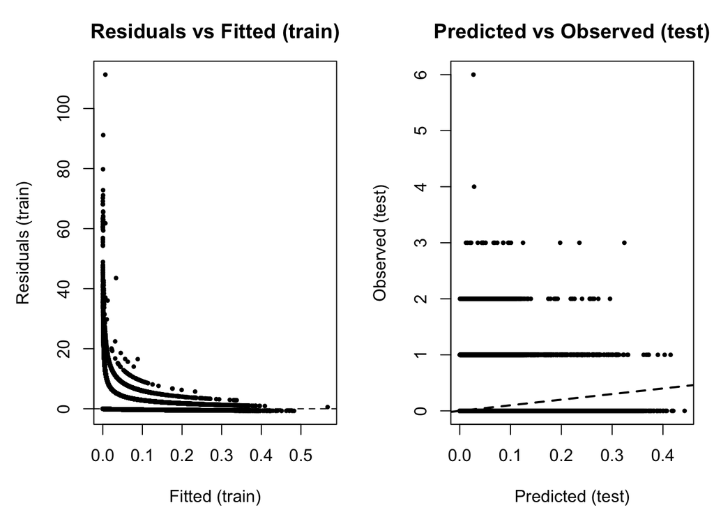

```r
# Poisson GLM:
par(mfrow = c(1, 2), mar = c(4.2, 4.6, 3, 1))

# Left: Residuals vs Fitted (train)
r_train <- residuals(fit_tr_p, type = "pearson")
f_train <- fitted(fit_tr_p)
plot(f_train, r_train, pch = 16, cex = 0.6,
     xlab = "Fitted (train)", ylab = "Residuals (train)",
     main = "Residuals vs Fitted (train)")
abline(h = 0, lty = 2)

# Right: Predicted vs Observed (test)
ok  <- !is.na(pred_te_p) & !is.na(te$ClaimNb)
yte <- te$ClaimNb[ok]
pte <- pred_te_p[ok]
plot(pte, yte, pch = 16, cex = 0.6,
     xlab = "Predicted (test)", ylab = "Observed (test)",
     main = "Predicted vs Observed (test)")
abline(0, 1, lty = 2, lwd = 2)
```

Figure 5: Model diagnostics for model 1.

## 5.3 Model 2: GLM (Negative Binomial)

The Negative Binomial GLM reduces over-dispersion compared to the Poisson model, as seen from the lower residual deviance and dispersion parameter. However, residuals still show a pattern of higher variance at low fitted values, and test predictions underestimate large observed counts. Overall, the model fits better than Poisson but still struggles with excess zeros and rare high claims.

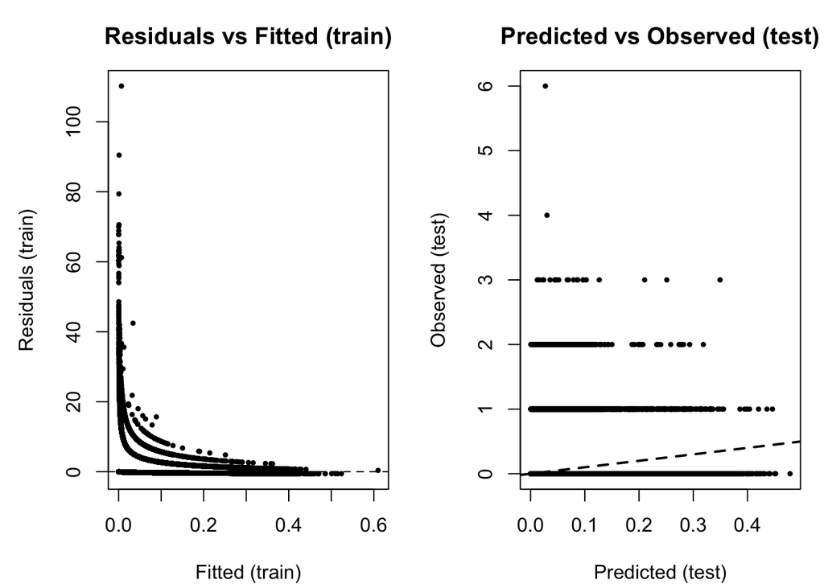

```r
#NegBin GLM:
par(mfrow = c(1, 2), mar = c(4.2, 4.6, 3, 1))

# Left: Residuals vs Fitted (train)
r_train_nb <- residuals(fit_tr_nb, type = "pearson")
f_train_nb <- fitted(fit_tr_nb)
plot(f_train_nb, r_train_nb, pch = 16, cex = 0.6,
     xlab = "Fitted (train)", ylab = "Residuals (train)",
     main = "Residuals vs Fitted (train)")
abline(h = 0, lty = 2)

# Right: Predicted vs Observed (test)
ok_nb  <- !is.na(pred_te_nb) & !is.na(te$ClaimNb)
yte_nb <- te$ClaimNb[ok_nb]
pte_nb <- pred_te_nb[ok_nb]
plot(pte_nb, yte_nb, pch = 16, cex = 0.6,
     xlab = "Predicted (test)", ylab = "Observed (test)",
     main = "Predicted vs Observed (test)")
abline(0, 1, lty = 2, lwd = 2)
```

Figure 6: Model diagnostics for model 2.

## 5.4 Model 3: GLM (Zero Inflated Poisson)

The Zero-Inflated Poisson model further improves fit by accounting for excess zeros. Residuals are more concentrated around zero, and dispersion decreases compared to the standard Poisson. Predictions align better with observed low claim counts, though higher claims remain slightly underestimated. Overall, this model handles zero-heavy data more effectively.

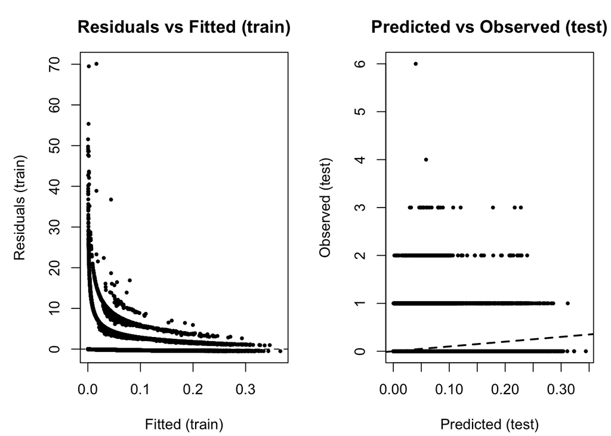

```r
# ZIP (zeroinfl):
par(mfrow = c(1, 2), mar = c(4.2, 4.6, 3, 1))

# Left: Residuals vs Fitted (train)
r_train_zp <- residuals(fit_tr_zp, type = "pearson")
f_train_zp <- fitted(fit_tr_zp)
plot(f_train_zp, r_train_zp, pch = 16, cex = 0.6,
     xlab = "Fitted (train)", ylab = "Residuals (train)",
     main = "Residuals vs Fitted (train)")
abline(h = 0, lty = 2)

# Right: Predicted vs Observed (test)
ok_zp  <- !is.na(pred_te_zp) & !is.na(te$ClaimNb)
yte_zp <- te$ClaimNb[ok_zp]
pte_zp <- pred_te_zp[ok_zp]
plot(pte_zp, yte_zp, pch = 16, cex = 0.6,
     xlab = "Predicted (test)", ylab = "Observed (test)",
     main = "Predicted vs Observed (test)")
abline(0, 1, lty = 2, lwd = 2)
```

Figure 7: Model diagnostics for model 3.

## 5.5 AUC-ROC

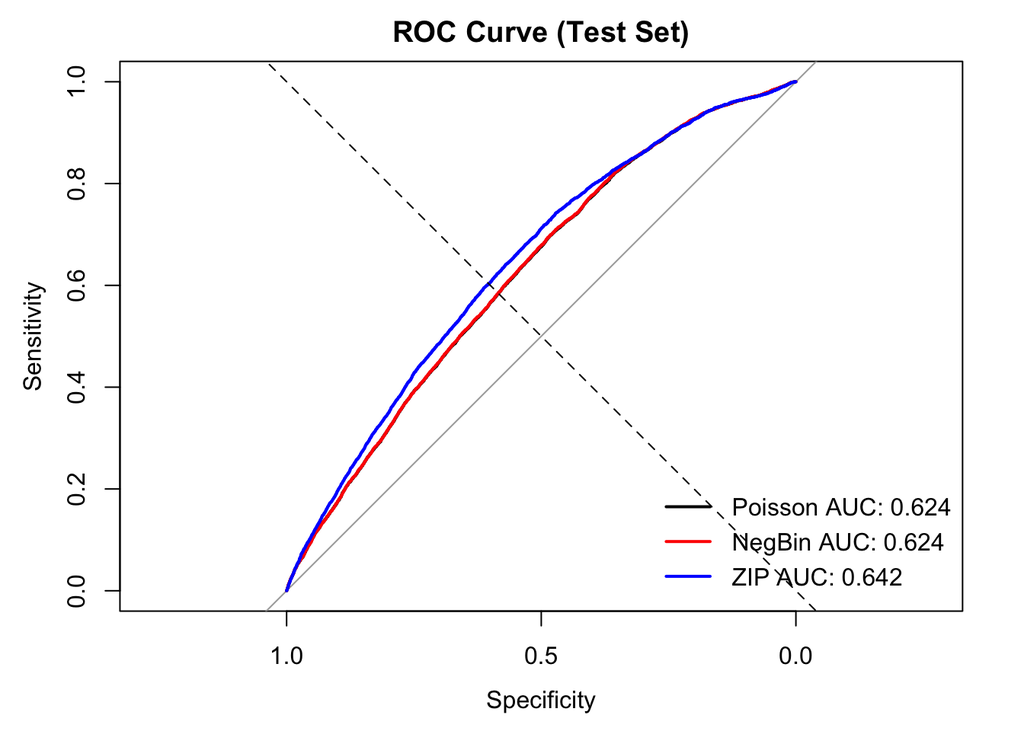

```r
y_te <- as.integer(te$ClaimNb > 0)

prob_p  <- 1 - exp(-pred_te_p)
theta   <- fit_tr_nb$theta
prob_nb <- 1 - (theta / (theta + pred_te_nb))^theta
pi_te   <- predict(fit_tr_zp, newdata = te, type = "zero")
lam_te  <- predict(fit_tr_zp, newdata = te, type = "count")
prob_zp <- 1 - (pi_te + (1 - pi_te) * exp(-lam_te))

roc_p  <- roc(y_te, prob_p)
roc_nb <- roc(y_te, prob_nb)
roc_zp <- roc(y_te, prob_zp)

plot(roc_p, lwd=2, main="ROC Curve (Test Set)")
lines(roc_nb, col="red", lwd=2)
lines(roc_zp, col="blue", lwd=2)
abline(0,1,lty=2)
legend("bottomright", c(
  paste("Poisson AUC:", round(auc(roc_p),3)),
  paste("NegBin AUC:", round(auc(roc_nb),3)),
  paste("ZIP AUC:", round(auc(roc_zp),3))
), col=c("black","red","blue"), lwd=2, bty="n")
```

Figure 8: AUC-ROC Curve.

# 6 Discussion

Key predictors such as driver age, vehicle age, power, and fuel type significantly influenced claim frequency, while regional effects indicated spatial variability in risk factors. These findings suggest that both demographic and contextual variables contribute to claim occurrence.

The results have practical relevance for insurance pricing and underwriting. Incorporating zero-inflated or hurdle models can improve premium calibration and risk segmentation, particularly for portfolios dominated by zero claims. Recognizing regional and vehicle-based variations can further enhance targeted pricing and risk management strategies.

# 7 Conclusion

The analysis compared Poisson, Negative Binomial, and Zero-Inflated Poisson (ZIP) models to predict insurance claim frequency. After addressing multicollinearity and transforming skewed variables, the ZIP model demonstrated the best overall fit and predictive accuracy, confirming that accounting for excess zeros substantially improves model performance. Key predictors included driver age, vehicle age, fuel type, vehicle power, and regional factors. Insurers are advised to adopt the ZIP model for claim frequency estimation, prioritize these influential predictors in pricing strategies, and use predicted claim probabilities to identify different risk segments.Regular model validation is recommended to ensure continued reliability and alignment with business objectives.

# 8 Future Work

The model performance can be improved by backward selection in recurrring manner. Here, the predictor filtering (such as keeping DriverAge and dropping BonusMalus and keeping Area and dropping Density) was also done without checking of the dropped predictor’s would provide better performance or stand out as better predictors for the models. These gaps should be addressed and check for the improvement of the models.

# 9 References

Dutang, C., & Charpentier, A. (2016). Casdatasets: Insurance datasets [R package version 1.0-6].  
FLOSER. (2019). French motor claims datasets fremtpl2freq [Data set]. Retrieved October 8, 2025, from, https://www.kaggle.com/datasets/floser/french-motor-claims-datasets-fremtpl2freq  
Marciuc, M. A. (2024). Predictive Modeling for Claims in Automobile Insurance. Review of Economic Studies and Research Virgil Madgearu, 17(2), 79-99.  
Simmachan, T., & Boonkrong, P. (2024). A Comparison of Count and Zero-Inflated Regression Models for Predicting Claim Frequencies in Thai Automobile Insurance. Lobachevskii Journal of Mathematics, 45(12), 6400-6414.

# 10 Supplimentary Materials

## 10.1 Checking VIF

VIF been checked for variables in trial error form to ensure removed variables are not redundant removal.

```r
#import libraries
library(data.table)
library(ggplot2)
library(splines)
library(MASS)
library(DHARMa)
library(dplyr)
library(MASS)
library(pROC)
library(ggplot2)
library(patchwork)
library(boot)
require(pscl)
library(pROC)

# load data
df <- as.data.frame(readxl::read_excel("/Users/mobasshirazaman/Library/CloudStorage/OneDrive-NorthernIllinoisUniversity/ASU/Fall2025/ACT560/Project1MZ/freMTPL2freq.xlsx"))

#transform predictors
top3 <- names(sort(table(df$VehBrand), decreasing = TRUE))[1:min(3, nlevels(factor(df$VehBrand)))]
df <- df %>%
  filter(Exposure > 0, Density > 0) %>%
  mutate(
    VehAge_grp  = cut(VehAge, c(-Inf, 0, 10, Inf), labels = c("0","1-10","11+"), right = TRUE),
    VehPower_hi = factor(ifelse(VehPower <= 8, "low", "high"), levels = c("low","high")),
    VehBrand3   = factor(ifelse(VehBrand %in% top3, as.character(VehBrand), "Other")),
    Density_log = log(Density)
  )


library(car)
library(performance)

# keep Exposure>0 and cast factors
df <- df %>% filter(Exposure > 0) %>%
  mutate(
    Area     = factor(Area),
    Region   = factor(Region),
    VehBrand3 = factor(VehBrand3),
    VehGas   = factor(VehGas),
    VehPower_hi= factor(VehPower_hi),
    VehAge_grp= factor(VehAge_grp),
  )
# with all
base_form_full <- ClaimNb ~ Area+ Region + VehBrand3 + VehGas +
  DrivAge + VehAge_grp + VehPower_hi + Density_log

m_lm_full <- lm(base_form_full, data = df)
# quick readout
print(car::vif(m_lm_full))
```

```
##                  GVIF Df GVIF^(1/(2*Df))
## Area        25.897169  5        1.384603
## Region       2.213116 21        1.019094
## VehBrand3    1.427390  3        1.061102
## VehGas       1.059247  1        1.029197
## DrivAge      1.032975  1        1.016354
## VehAge_grp   1.227738  2        1.052632
## VehPower_hi  1.043805  1        1.021668
## Density_log 19.911956  1        4.462281
```

```r
performance::check_collinearity(m_lm_full)
```

| Term | VIF | VIF_CI_low | VIF_CI_high | SE_factor | Tolerance | Tolerance_CI_low | Tolerance_CI_high |
| --- | --- | --- | --- | --- | --- | --- | --- |
| Area | 25.897169 | 25.776564 | 26.018362 | 1.384603 | 0.03861426 | 0.03843440 | 0.03879493 |
| Region | 2.213116 | 2.204988 | 2.221298 | 1.019094 | 0.45185160 | 0.45018715 | 0.45351713 |
| VehBrand3 | 1.427390 | 1.422998 | 1.431828 | 1.061102 | 0.70057922 | 0.69840797 | 0.70274148 |
| VehGas | 1.059247 | 1.056644 | 1.061970 | 1.029197 | 0.94406669 | 0.94164609 | 0.94639259 |
| DrivAge | 1.032975 | 1.030533 | 1.035612 | 1.016354 | 0.96807752 | 0.96561223 | 0.97037150 |
| VehAge_grp | 1.227738 | 1.224300 | 1.231229 | 1.052632 | 0.81450612 | 0.81219687 | 0.81679339 |
| VehPower_hi | 1.043805 | 1.041291 | 1.046471 | 1.021668 | 0.95803380 | 0.95559247 | 0.96034649 |
| Density_log | 19.911956 | 19.819775 | 20.004589 | 4.462281 | 0.05022108 | 0.04998853 | 0.05045466 |

```r
# without density
base_form_full <- ClaimNb ~ Area+ Region + VehBrand3 + VehGas +
  DrivAge + VehAge_grp + VehPower_hi

m_lm_full <- lm(base_form_full, data = df)
# quick readout
print(car::vif(m_lm_full))
```

```
##                 GVIF Df GVIF^(1/(2*Df))
## Area        1.844680  5        1.063144
## Region      2.161645 21        1.018524
## VehBrand3   1.426610  3        1.061005
## VehGas      1.058723  1        1.028942
## DrivAge     1.032963  1        1.016348
## VehAge_grp  1.227676  2        1.052618
## VehPower_hi 1.043764  1        1.021648
```

```r
performance::check_collinearity(m_lm_full)
```

| Term | VIF | VIF_CI_low | VIF_CI_high | SE_factor | Tolerance | Tolerance_CI_low | Tolerance_CI_high |
| --- | --- | --- | --- | --- | --- | --- | --- |
| Area | 1.844680 | 1.838303 | 1.851106 | 1.063144 | 0.5420993 | 0.5402176 | 0.5439798 |
| Region | 2.161645 | 2.153762 | 2.169582 | 1.018524 | 0.4626106 | 0.4609182 | 0.4643038 |
| VehBrand3 | 1.426610 | 1.422222 | 1.431044 | 1.061005 | 0.7009624 | 0.6987906 | 0.7031252 |
| VehGas | 1.058723 | 1.056122 | 1.061443 | 1.028942 | 0.9445345 | 0.9421133 | 0.9468601 |
| DrivAge | 1.032963 | 1.030521 | 1.035600 | 1.016348 | 0.9680891 | 0.9656238 | 0.9703831 |
| VehAge_grp | 1.227676 | 1.224239 | 1.231167 | 1.052618 | 0.8145470 | 0.8122377 | 0.8168343 |
| VehPower_hi | 1.043764 | 1.041251 | 1.046431 | 1.021648 | 0.9580708 | 0.9556294 | 0.9603835 |

```r
# without area
base_form_full <- ClaimNb ~  Region + VehBrand3 + VehGas +
  DrivAge + VehAge_grp + VehPower_hi + Density_log

m_lm_full <- lm(base_form_full, data = df)
# quick readout
print(car::vif(m_lm_full))
```

```
##                 GVIF Df GVIF^(1/(2*Df))
## Region      1.676523 21        1.012379
## VehBrand3   1.426807  3        1.061030
## VehGas      1.058974  1        1.029065
## DrivAge     1.031768  1        1.015760
## VehAge_grp  1.227034  2        1.052481
## VehPower_hi 1.042466  1        1.021012
## Density_log 1.418348  1        1.190944
```

```r
performance::check_collinearity(m_lm_full)
```

| Term | VIF | VIF_CI_low | VIF_CI_high | SE_factor | Tolerance | Tolerance_CI_low | Tolerance_CI_high |
| --- | --- | --- | --- | --- | --- | --- | --- |
| Region | 1.676523 | 1.670945 | 1.682146 | 1.012379 | 0.5964727 | 0.5944786 | 0.5984637 |
| VehBrand3 | 1.426807 | 1.422417 | 1.431241 | 1.061030 | 0.7008658 | 0.6986941 | 0.7030285 |
| VehGas | 1.058974 | 1.056373 | 1.061696 | 1.029065 | 0.9443100 | 0.9418891 | 0.9466357 |
| DrivAge | 1.031768 | 1.029335 | 1.034403 | 1.015760 | 0.9692103 | 0.9667414 | 0.9715014 |
| VehAge_grp | 1.227034 | 1.223599 | 1.230521 | 1.052481 | 0.8149735 | 0.8126638 | 0.8172611 |
| VehPower_hi | 1.042466 | 1.039960 | 1.045128 | 1.021012 | 0.9592641 | 0.9568204 | 0.9615751 |
| Density_log | 1.418348 | 1.413999 | 1.422742 | 1.190944 | 0.7050457 | 0.7028679 | 0.7072141 |